# Graficos-practice

Francisco

2024-10-17

Este rmarkdown sirve para practicar las funciones del tema de representación gráfica con `plot()` del curso de Estadística descriptiva con `R` y `Python`

## Gráficos con la función `plot`

Así se hace un gráfico de puntos con la función `plot()`:

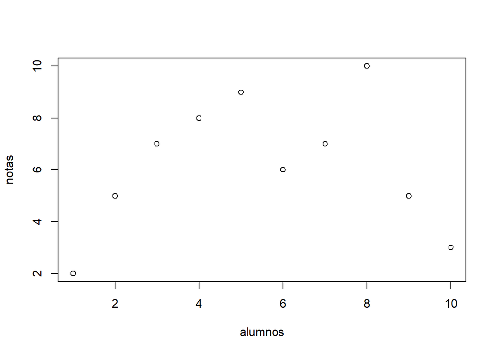

Fig.1 Gráfico con plot

```r
x = 1
alumnos = 1:10
notas = c(2,5,7,8,9,6,7,10,5,3)
plot(alumnos, notas)
```

Si solo suministramos `x` sin el parámetro `y` a la función `plot(x,y)`, `R` tomará a `x`como `y`, y a `x` como `1:length(x)`, o bien: `plot(x) = plot(1:length(x),x)`

Si queremos representar una función $f(x)$:

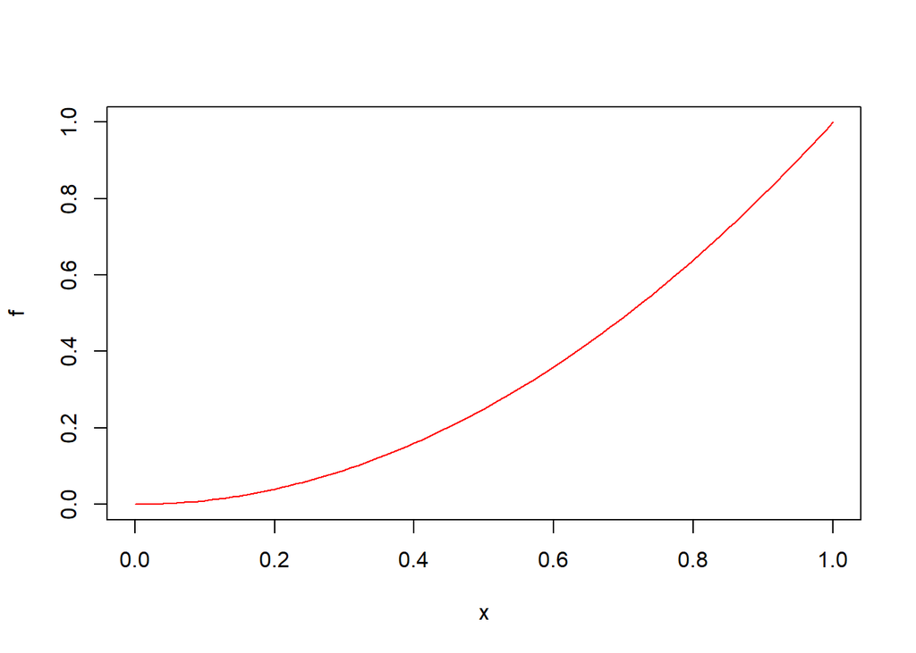

```r
f <- function(x){x^2}

plot(f,col="red")
```

## Parámetros de la función plot

Modificamos el gráfico de la Fig. 1 con los siguientes parámetros:

- `main('título')`: para indicar un título al gráfico. Tambíen podemos colocar una ecuación con `LaTeX` con `expression()`
- `xlab(), ylab()`: Títulos a los ejes
- `pch = n`: Todos los códigos de los símbolos se encuentran en las diapositivas
- `col = "color name"`: los códigos de colores se encuentran en el repositorio
- `log`: indicamos que queremos el gráfico en escala logarítmica

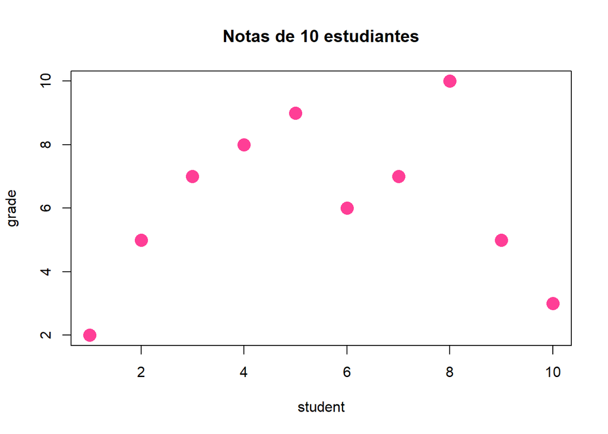

```r
plot(alumnos,notas,main= "Notas de 10 estudiantes",xlab = "student",ylab = "grade",col = "violetred1",pch= 16,cex = 2)
```

Graficando la sucesión de Fibonacci.

```r
n = 1:20
fib = (1/sqrt(5))*((1+sqrt(5))/2)^n - (1/sqrt(5))*((1-sqrt(5))/2)^n
fib
```

```
##  [1]    1    1    2    3    5    8   13   21   34   55   89  144  233  377  610
## [16]  987 1597 2584 4181 6765
```

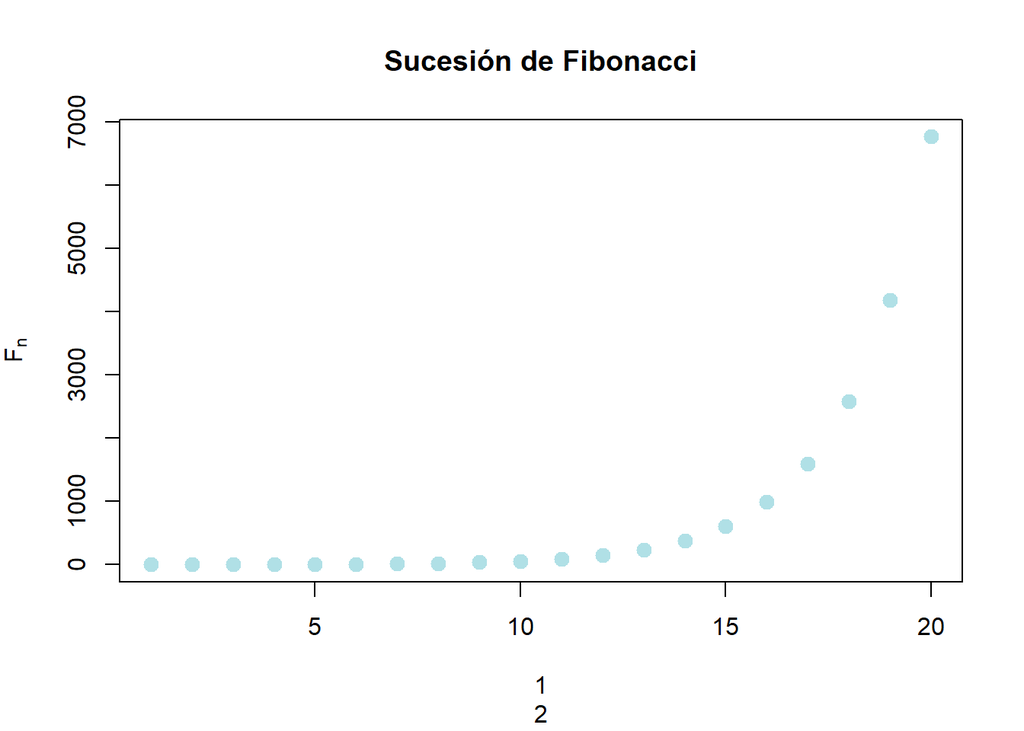

```r
plot(fib,xlab = n,ylab = expression(F[n]),main = "Sucesión de Fibonacci",pch = 20,col="powderblue",cex=2)
```

Si queremos cambiar la distribución de los gráficos, podemos usar el parámetro de configuración `par(mfrow=c(...)` indicando la disposición. En el ejemplo siguientes se utiliza la disposición 1 fila, 2 columnas.

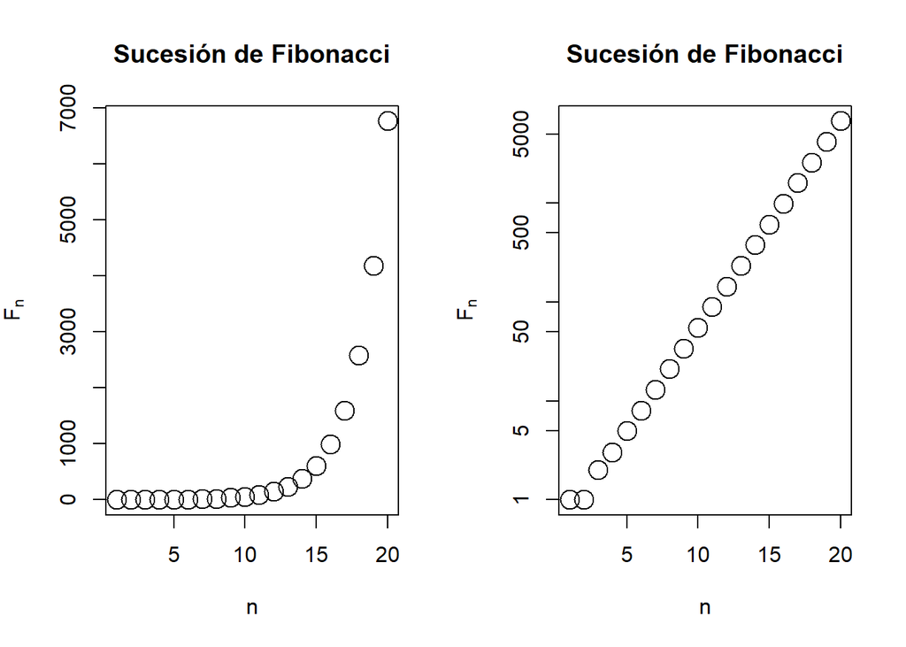

## Parámetros de la función plot - tipo de gráfico

- type: para elegir el tipo de gráfico que queremos:
  - p: puntos (valor por defecto)
  - l: líneas rectas que unen los puntos (dichos puntos no tienen símbolo)
  - b: líneas rectas que unen los puntos (dichos puntos tienen símbolo). Las líneas no traspasan los puntos
  - o: como el anterior pero en este caso las líneas sí que traspasan los puntos
  - h: histograma de líneas
  - s: histograma de escalones
  - n: para no dibujar los puntos

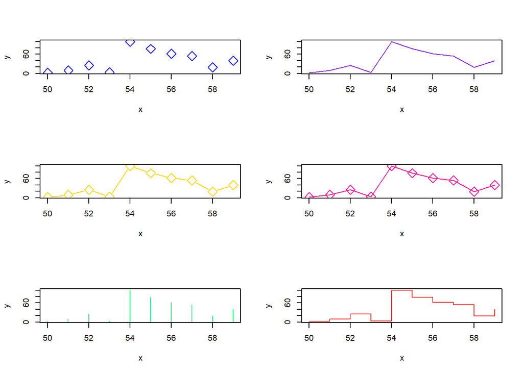

```r
par(mfrow = c(3,2))
x = c(50:59)
y = c(2,9,25,3,100,77,62,54,19,40)
plot(x,y, pch = 23, cex = 2, col = "blue", type = "p")
plot(x,y, pch = 23, cex = 2, col = "blueviolet", type = "l")
plot(x,y, pch = 23, cex = 2, col = "gold", type = "b")
plot(x,y, pch = 23, cex = 2, col = "deeppink", type = "o")
plot(x,y, pch = 23, cex = 2, col = "springgreen", type = "h")
plot(x,y, pch = 23, cex = 2, col = "firebrick1", type = "s")
```

```r
par(mfrow = c(1,1))
```

## Parámetros de la función plot

- `lty`: para especificar el tipo de línea
  - “solid” : $1$: línea continua (valor por defecto)
  - “dashed” : $2$: línea discontinua
  - “dotted” : $3$: línea de puntos
  - “dotdashed” : $4$: línea que alterna puntos y rayas
- `lwd`: para especificar el grosor de las líneas
- `xlim`: para modificar el rango del eje $X$
- `ylim`: para modificar el rango del eje $Y$
- `xaxp`: para modificar posiciones de las marcas en el eje $X$
- `yaxp`: para modificar posiciones de las marcas en el eje $Y$

El gráfico siguiente muestra el uso de los parámetros anteriores:

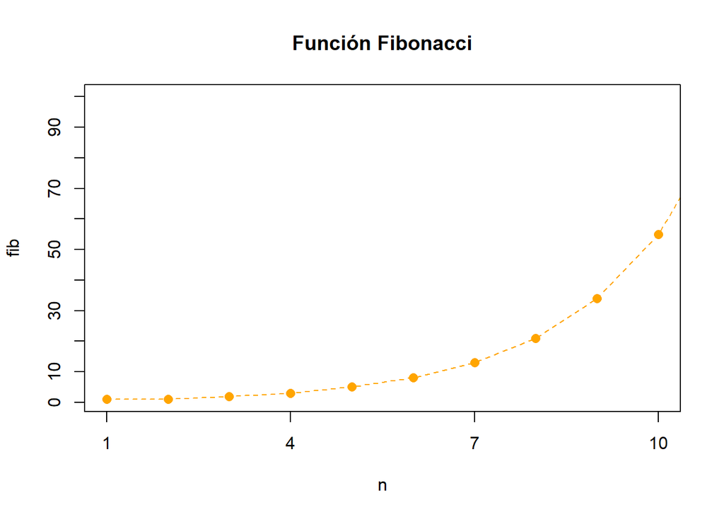

```r
plot(n,fib,main="Función Fibonacci",type = "o",cex=1.2,pch=16,
     col = 'orange',lty="dashed",lwd = 1.2,xlim = c(1,10),ylim =c(1,100),
     xaxp = c(1,10,3),yaxp = c(0,100,10))
```